# Car Prices

## Graphical Summary

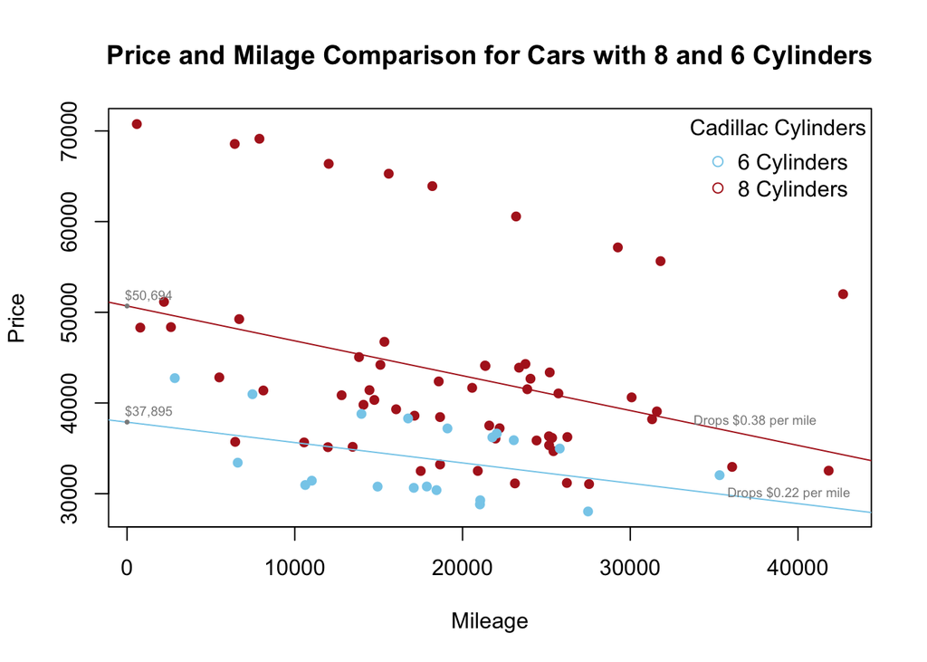

```r
palette(c("skyblue","firebrick"))

plot(Price ~ Mileage, data=car1, col= Cylinder, main="Price and Milage Comparison for Cars with 8 and 6 Cylinders", pch=16)

car.lm <- lm(Price ~  Mileage + Cylinder + Mileage:Cylinder, data=car1)

c <- coef(car.lm)
abline(c[1], c[2], col=palette()[1])

abline(c[1]+c[3], c[2]+c[4], col=palette()[2])

text(1300,37895, "$37,895", cex=0.6, col="gray55", pos=3, offset=.25)
  points(0,37895, pch=16, col="gray55", cex=0.5)

text(1300,50694, "$50,694", cex=0.6, col="gray55", pos=3, offset=.25)
  points(0,50694, pch=16, col="gray55", cex=0.5)

 # Add text for depreciation rates:
  text(35000, 30000, "Drops $0.22 per mile", cex=0.6, col="gray55", pos=4)
  text(33000, 38000, "Drops $0.38 per mile", cex=0.6, col="gray55", pos=4)

legend("topright", legend=c("6 Cylinders","8 Cylinders"), pch=1, col=palette(), title="Cadillac Cylinders", bty="n")
```

## Slope and Y-intercept of both lines

$$\text{Y-intercept and Slope baseline}$$

$$\hat{Y}_i = \overbrace{37895}^{\stackrel{\text{y-int}}{\text{baseline}}} - \overbrace{0.2247}^{\stackrel{\text{slope}}{\text{baseline}}} X_{1i}$$

$$\text{Y-intercept and Slope 2nd Line}$$

$$\hat{Y}_i = \overbrace{50694}^{\stackrel{\text{y-int}}{\text{2nd Line}}} - \overbrace{0.3842}^{\stackrel{\text{slope}}{\text{2nd Line}}} X_{1i}$$
This table shows the actual numbers used in the conclusion given at the end of the analysis.

## Multiple Linear Regression Model Analysis

```r
car.lm <- lm(Price ~  Mileage + Cylinder + Mileage:Cylinder, data=car1)
```

```r
pander(car.lm, caption="Regression Summary for Price Output on Mileage According to Cylinder Type")
```

Regression Summary for Price Output on Mileage According to Cylinder Type

|  | Estimate | Std. Error | t value | Pr(>\|t\|) |
| --- | --- | --- | --- | --- |
| **(Intercept)** | 37895 | 4998 | 7.582 | 6.925e-11 |
| **Mileage** | -0.2247 | 0.2598 | -0.8649 | 0.3898 |
| **Cylinder8** | 12799 | 5632 | 2.273 | 0.02587 |
| **Mileage:Cylinder8** | -0.1595 | 0.2866 | -0.5566 | 0.5794 |

β0 is represented by the Intercept as the coefficient estimate

β1 is represented by Mileage as the coefficient estimate

β2 is represented by Cylinder8 as the coefficient estimate

β3 is represented by Mileage:Cylinder8 as the coefficient estimate

Cylinder8 is the difference between the two y-intercepts

Mileage:Cylinder8 is the difference between the two slopes

## Requirements with the Regression

```r
par(mfrow=c(1,3))
plot(car.lm, which=1)
qqPlot(car.lm$residuals)
```

```
## [1] 73 75
```

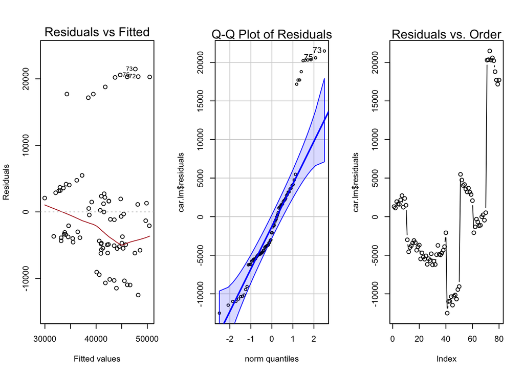

```r
mtext(side=3,text="Q-Q Plot of Residuals")
plot(car.lm$residuals, type="b")
mtext(side=3, text="Residuals vs. Order")
```

## Simple Linear Regression

### Graphical Summary

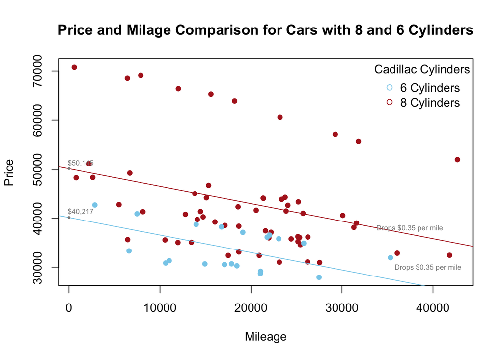

```r
palette(c("skyblue","firebrick"))

plot(Price ~ Mileage, data=car1, col= Cylinder, main="Price and Milage Comparison for Cars with 8 and 6 Cylinders", pch=16)

car.lm2 <- lm(Price ~  Mileage + Cylinder, data=car1)

c <- coef(car.lm2)
abline(c[1], c[2], col=palette()[1])

abline(c[1]+c[3], c[2], col=palette()[2])

text(1300,40217, "$40,217", cex=0.6, col="gray55", pos=3, offset=.25)
  points(0,40217, pch=16, col="gray55", cex=0.5)

text(1300,50145, "$50,145", cex=0.6, col="gray55", pos=3, offset=.25)
  points(0,50145, pch=16, col="gray55", cex=0.5)

 # Add text for depreciation rates:
  text(35000, 30000, "Drops $0.35 per mile", cex=0.6, col="gray55", pos=4)
  text(33000, 38000, "Drops $0.35 per mile", cex=0.6, col="gray55", pos=4)

legend("topright", legend=c("6 Cylinders","8 Cylinders"), pch=1, col=palette(), title="Cadillac Cylinders", bty="n")
```

### Slope and Y-intercept

The slopes and y-intercept can be placed as an “in between” range between the two slopes and y-intercepts of the multiple linear regression that were shown before.

Regression Equation for Mileage or 1st intercept
$$\hat{Y}_i = \overbrace{40217}^{\stackrel{\text{y-int Mileage}}{\text{}}} - \overbrace{0.3557}^{\stackrel{\text{slope}}{\text{}}} X_{1i}$$
Regression Equation for Cylinder or 2nd intercept

$$\hat{Y}_i = \overbrace{50145}^{\stackrel{\text{y-int Cylinder}}{\text{}}} - \overbrace{0.3557}^{\stackrel{\text{slope}}{\text{}}} X_{1i}$$